# Intro to Data Science - HW 3

##### Copyright Jeffrey Stanton, Jeffrey Saltz, and Jasmina Tacheva

```r
# Enter your name here: Sana Khan, IST 687, Homework 2, Due 1/1
```

### Attribution statement: (choose only one and delete the rest)

```r
# 1. I did this homework by myself, with help from the book and the professor.
```

### Reminders of things to practice from last week:

Make a data frame data.frame( )  
Row index of max/min which.max( ) which.min( )  
Sort value or order rows sort( ) order( )  
Descriptive statistics mean( ) sum( ) max( )  
Conditional statement if (condition) “true stuff” else “false stuff”

### This Week:

Often, when you get a dataset, it is not in the format you want. You can (and should) use code to refine the dataset to become more useful. As Chapter 6 of Introduction to Data Science mentions, this is called “data munging.” In this homework, you will read in a dataset from the web and work on it (in a data frame) to improve its usefulness.

## Part 1: Use read_csv( ) to read a CSV file from the web into a data frame:

1. Use R code to read directly from a URL on the web. Store the dataset into a new dataframe, called dfComps.  
   The URL is:  
   “https://intro-datascience.s3.us-east-2.amazonaws.com/companies1.csv”  
   **Hint:** use read_csv( ), not read.csv( ). This is from the **tidyverse package**. Check the help to compare them.

```r
#install.packages("tidyverse")
library(tidyverse)
dfComps <- data.frame(read_csv(url("https://intro-datascience.s3.us-east-2.amazonaws.com/companies1.csv")))
```

## Part 2: Create a new data frame that only contains companies with a homepage URL:

5. Use **subsetting** to create a new dataframe that contains only the companies with homepage URLs (store that dataframe in **urlComps**).

```r
urlComps <- subset(dfComps, homepage_url != 'NA' )
```

4. How many companies are missing a homepage URL?

```r
#3323
no_url <-dfComps[is.na(dfComps$homepage_url), ]
str(no_url)
```

```
## 'data.frame':    3323 obs. of  18 variables:
##  $ permalink        : chr  "/organization/r-ranch-and-mine" "/organization/1-4-all" "/organization/1-618-technology" "/organization/121-rentals" ...
##  $ name             : chr  "-R- Ranch and Mine" "1-4 All" "1.618 Technology" "121 Rentals" ...
##  $ homepage_url     : chr  NA NA NA NA ...
##  $ category_list    : chr  "|Entertainment|Games|" "|Entertainment|Games|Software|" "|Real Estate|" "|Real Estate|" ...
##  $ market           : chr  "Games" "Software" "Real Estate" "Real Estate" ...
##  $ funding_total_usd: chr  "10 000" "-" "-" "-" ...
##  $ status           : chr  "operating" "operating" "operating" "operating" ...
##  $ country_code     : chr  "USA" "USA" "USA" "USA" ...
##  $ state_code       : chr  "TX" "NC" "FL" "TX" ...
##  $ region           : chr  "Dallas" "NC - Other" "Orlando" "TX - Other" ...
##  $ city             : chr  "Fort Worth" "Connellys Springs" "Orlando" "Amarillo" ...
##  $ funding_rounds   : num  1 1 1 1 1 1 1 5 1 2 ...
##  $ founded_at       : chr  "8/7/14" NA "7/12/13" "12/4/11" ...
##  $ founded_month    : chr  "2014-07" NA "2013-12" "2011-04" ...
##  $ founded_quarter  : chr  "2014-Q3" NA "2013-Q4" "2011-Q2" ...
##  $ founded_year     : num  2014 NA 2013 2011 2006 ...
##  $ first_funding_at : chr  "17/08/2014" "21/04/2013" "22/01/2014" "3/9/14" ...
##  $ last_funding_at  : chr  "17/08/2014" "21/04/2013" "22/01/2014" "3/9/14" ...
```

## Part 3: Analyze the numeric variables in the dataframe.

7. How many **numeric variables** does the dataframe have? You can figure that out by looking at the output of **str(urlComps)**.
8. What is the average number of funding rounds for the companies in **urlComps**?

```r
str(urlComps)
```

```
## 'data.frame':    44435 obs. of  18 variables:
##  $ permalink        : chr  "/organization/waywire" "/organization/tv-communications" "/organization/rock-your-paper" "/organization/in-touch-network" ...
##  $ name             : chr  "#waywire" "&TV Communications" "'Rock' Your Paper" "(In)Touch Network" ...
##  $ homepage_url     : chr  "http://www.waywire.com" "http://enjoyandtv.com" "http://www.rockyourpaper.org" "http://www.InTouchNetwork.com" ...
##  $ category_list    : chr  "|Entertainment|Politics|Social Media|News|" "|Games|" "|Publishing|Education|" "|Electronics|Guides|Coffee|Restaurants|Music|iPhone|Apps|Mobile|iOS|E-Commerce|" ...
##  $ market           : chr  "News" "Games" "Publishing" "Electronics" ...
##  $ funding_total_usd: chr  "1 750 000" "4 000 000" "40 000" "1 500 000" ...
##  $ status           : chr  "acquired" "operating" "operating" "operating" ...
##  $ country_code     : chr  "USA" "USA" "EST" "GBR" ...
##  $ state_code       : chr  "NY" "CA" NA NA ...
##  $ region           : chr  "New York City" "Los Angeles" "Tallinn" "London" ...
##  $ city             : chr  "New York" "Los Angeles" "Tallinn" "London" ...
##  $ funding_rounds   : num  1 2 1 1 2 1 1 1 1 1 ...
##  $ founded_at       : chr  "1/6/12" NA "26/10/2012" "1/4/11" ...
##  $ founded_month    : chr  "2012-06" NA "2012-10" "2011-04" ...
##  $ founded_quarter  : chr  "2012-Q2" NA "2012-Q4" "2011-Q2" ...
##  $ founded_year     : num  2012 NA 2012 2011 2012 ...
##  $ first_funding_at : chr  "30/06/2012" "4/6/10" "9/8/12" "1/4/11" ...
##  $ last_funding_at  : chr  "30/06/2012" "23/09/2010" "9/8/12" "1/4/11" ...
```

```r
#G. 2 - funding rounds and founded year
mean(urlComps$funding_rounds)
```

```
## [1] 1.725194
```

```r
#H.The average funding was 1.725194 rounds
```

1. What year was the oldest company in the dataframe founded?  
   **Hint:** If you get a value of “NA,” most likely there are missing values in this variable which preclude R from properly calculating the min & max values. You can ignore NAs with basic math calculations. For example, instead of running mean(urlComps$founded_year), something like this will work for determining the average (note that this question needs to use a different function than ‘mean’.

```r
#mean(urlComps$founded_year, na.rm=TRUE)

#your code goes here
min(urlComps$founded_year, na.rm=TRUE)
```

```
## [1] 1900
```

```r
#The oldest company was founded in 1900

## Part 4:  Use string operations to clean the data.
```

11. The **permalink variable** in **urlComps** contains the name of each company but the names are currently preceded by the prefix “/organization/”. We can use str_replace() in tidyverse or gsub() to clean the values of this variable:

```r
urlComps$permalink <- str_replace(urlComps$permalink, '/organization/', "" )
```

12. Can you identify another variable which should be numeric but is currently coded as character? Use the as.numeric() function to add a new variable to **urlComps** which contains the values from the char variable as numbers. Do you notice anything about the number of NA values in this new column compared to the original “char” one?

```r
glimpse(urlComps)
```

```
## Rows: 44,435
## Columns: 18
## $ permalink         <chr> "waywire", "tv-communications", "rock-your-paper", "…
## $ name              <chr> "#waywire", "&TV Communications", "'Rock' Your Paper…
## $ homepage_url      <chr> "http://www.waywire.com", "http://enjoyandtv.com", "…
## $ category_list     <chr> "|Entertainment|Politics|Social Media|News|", "|Game…
## $ market            <chr> "News", "Games", "Publishing", "Electronics", "Softw…
## $ funding_total_usd <chr> "1 750 000", "4 000 000", "40 000", "1 500 000", "1 …
## $ status            <chr> "acquired", "operating", "operating", "operating", "…
## $ country_code      <chr> "USA", "USA", "EST", "GBR", "USA", "USA", "ARG", NA,…
## $ state_code        <chr> "NY", "CA", NA, NA, "NY", "FL", NA, NA, "IL", NA, "C…
## $ region            <chr> "New York City", "Los Angeles", "Tallinn", "London",…
## $ city              <chr> "New York", "Los Angeles", "Tallinn", "London", "New…
## $ funding_rounds    <dbl> 1, 2, 1, 1, 2, 1, 1, 1, 1, 1, 2, 1, 1, 1, 4, 1, 1, 1…
## $ founded_at        <chr> "1/6/12", NA, "26/10/2012", "1/4/11", "1/1/12", "10/…
## $ founded_month     <chr> "2012-06", NA, "2012-10", "2011-04", "2012-01", "201…
## $ founded_quarter   <chr> "2012-Q2", NA, "2012-Q4", "2011-Q2", "2012-Q1", "201…
## $ founded_year      <dbl> 2012, NA, 2012, 2011, 2012, 2011, NA, 2007, 2010, NA…
## $ first_funding_at  <chr> "30/06/2012", "4/6/10", "9/8/12", "1/4/11", "29/08/2…
## $ last_funding_at   <chr> "30/06/2012", "23/09/2010", "9/8/12", "1/4/11", "4/9…
```

```r
# funding_total_usd should be numeric but is coded as a character
urlComps$funding_new <- as.numeric(urlComps$funding_total_usd) #code to convert values to numeric
which(is.na(urlComps$funding_total_usd)) #finds index of any NA values
```

```
## integer(0)
```

```r
#which(is.na(urlComps$funding_new)) # all values are showing as NA
```

13. To ensure the char values are converted correctly, we first need to remove the spaces between the digits in the variable. Check if this works, and explain what it is doing:

```r
library(stringi)
urlComps$funding_new <- stri_replace_all_charclass(urlComps$funding_total_usd,"\\p{WHITE_SPACE}", "")

#The above code is removing any whitespace that is found in the variable
```

[output not shown]

N. You are now ready to convert **urlComps$funding_new** to numeric using as.numeric().

Calculate the average funding amount for **urlComps**. If you get “NA,” try using the **na.rm=TRUE** argument from problem I.

```r
urlComps$funding_new <- as.numeric(urlComps$funding_new)
mean(urlComps$funding_new, na.rm=TRUE)
```

```
## [1] 18321551
```

```r
# Mean for funding is 18321551
```

Sample three unique observations from urlComps$funding_rounds, store the results in the vector ‘observations’

```r
obvervations <- sample(urlComps$funding_rounds, size = 3, replace = TRUE)
obvervations
```

```
## [1] 2 1 1
```

Take the mean of those observations

```r
mean(obvervations)
```

```
## [1] 1.333333
```

Do the two steps (sampling and taking the mean) in one line of code

```r
 mean(sample(urlComps$funding_rounds, size = 3, replace = TRUE))
```

```
## [1] 1.666667
```

Explain why the two means are (or might be) different

```r
# The two means are different because each sample being taken has different values from the sample size.
```

Use the replicate( ) function to repeat your sampling of three observations of urlComps$funding_rounds observations five times. The first argument to replicate( ) is the number of repeats you want. The second argument is the little chunk of code you want repeated.

```r
funding_sample <- replicate(5,mean(sample(urlComps$funding_rounds, size = 3, replace = TRUE)), simplify = TRUE)
funding_sample
```

```
## [1] 1.333333 1.000000 1.666667 1.333333 2.666667
```

Rerun your replication, this time doing 20 replications and storing the output of replicate() in a variable called **values**.

```r
 values  <- replicate(20,mean(sample(urlComps$funding_rounds, size = 3, replace = TRUE)),simplify = TRUE)
```

Generate a **histogram** of the means stored in **values**.

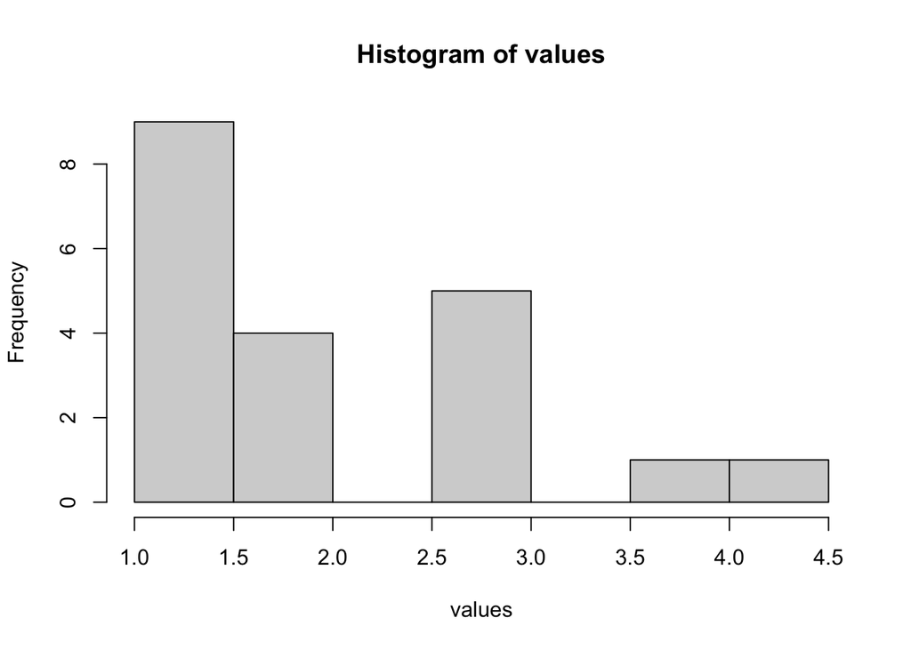

```r
hist(values)
```

Rerun your replication, this time doing 1000 replications and storing the output of replicate() in a variable called **values**, and then generate a histogram of **values**.

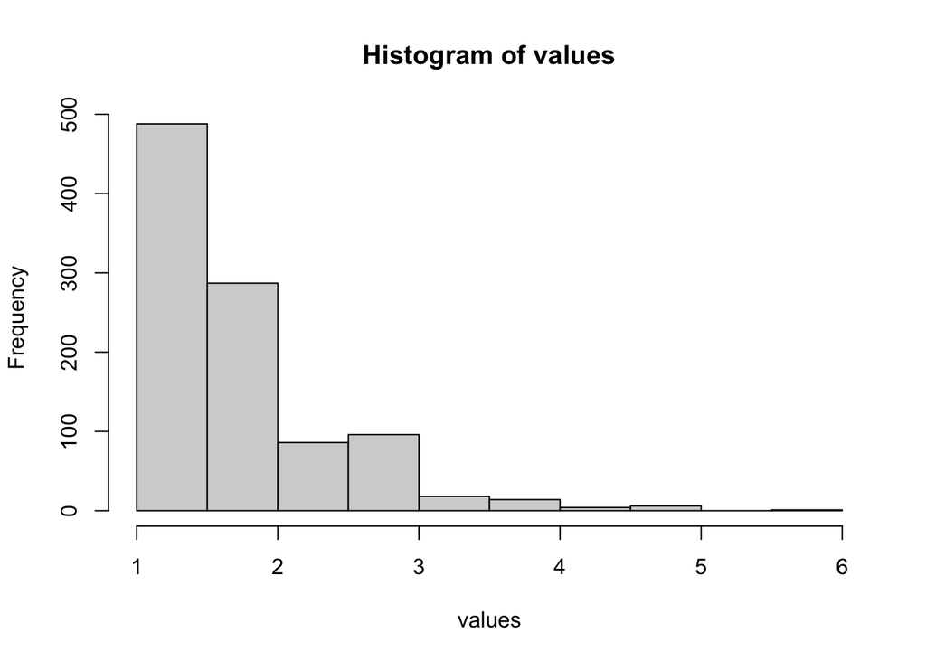

```r
values <- replicate(1000,mean(sample(urlComps$funding_rounds, size = 3, replace = TRUE)),simplify = TRUE)
hist(values)
```

Repeat the replicated sampling, but this time, raise your sample size from 3 to 22. How does that affect your histogram? Explain in a comment.

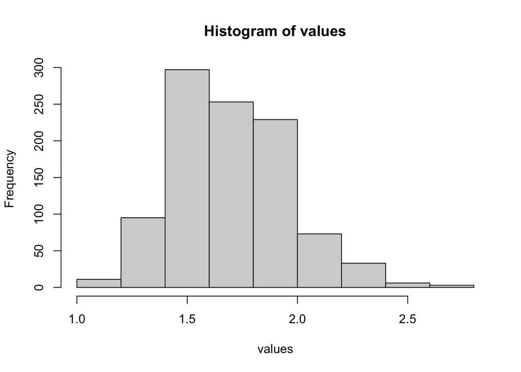

```r
values <- replicate(1000,mean(sample(urlComps$funding_rounds, size = 22, replace = TRUE)),simplify = TRUE)
hist(values)
```

```r
# When the sample size is 22, the distribution of the frequency is closer to a normal distribution. This is because you have a larger population size, which is more representative of the entire population
```

Explain in a comment below, the last three histograms, why do they look different?

```r
# Each histogram looks different because the number of replications and sample size is different. The first and second graph have the same population size of 3 which is relatively small. The middle graph has a higher replication number, and shows that the distribution skews to the right. The last graph has a larger sample size and has a more normal distribution since it has a better representation of the population. The standard devation on this graph is also lower than the first two graphs.
```